# Machine Learning Project

Hui ZENG

2020/5/24

## Installing Packages and Getting Data

```r
library(tibble)
library(bitops)
library(rpart)
library(rattle)
```

```r
library(e1071)
library(ggplot2)
library(lattice)
library(caret)
library(kernlab)
library(randomForest)
library(gbm)
```

## Getting and Cleaning Data

Read data from computer and check the dimension of two datasets. Data from testing dataset is for testing and data from training dataset is for training

```r
traindata <- read.csv('~/Downloads/pml-training.csv', header = TRUE, na.strings=c("NA","#DIV/0!",""))
validdata <- read.csv('~/Downloads/pml-testing.csv', header = TRUE, na.strings=c("NA","#DIV/0!",""))
dim(traindata);dim(validdata)
```

```
## [1] 19622   160
```

```
## [1]  20 160
```

## Getting Training Data Set and Testing Data Set

training datasets divided into two parts. 70% data is in training set and 30% data is in testing set

```r
set.seed(2332)
inTrain <- createDataPartition(traindata$classe, p = 0.7, list = FALSE)
trainset <- traindata[inTrain, ]
testset <- traindata[-inTrain, ]
dim(trainset);dim(testset)
```

```
## [1] 13737   160
```

```
## [1] 5885  160
```

## Continue to Clean Data

remove variance of some variables which equal to zero and keep the columns of training set and testing set same

```r
nzv <- nearZeroVar(trainset, saveMetrics=TRUE)
trainset <- trainset[,nzv$nzv==FALSE]
nzv<- nearZeroVar(testset,saveMetrics=TRUE)
testset <- testset[,nzv$nzv==FALSE]

trainset <- trainset[c(-1)]

training <- trainset
for(i in 1:length(trainset)) {
  if( sum( is.na( trainset[, i] ) ) /nrow(trainset) >= .7) {
    for(j in 1:length(training)) {
      if( length( grep(names(trainset[i]), names(training)[j]) ) == 1)  {
        training <- training[ , -j]
      }
    }
  }
}
trainset <- training
rm(training)

clean1 <- colnames(trainset)
clean2 <- colnames(trainset[, -58])
testset<- testset[clean1]
dim(testset)
```

```
## [1] 5885   58
```

```r
for (i in 1:length(testset) ) {
  for(j in 1:length(trainset)) {
    if( length( grep(names(trainset[i]), names(testset)[j]) ) == 1)  {
      class(testset[j]) <- class(trainset[i])
    }
  }
}
testset <- rbind(trainset[2, ] , testset)
testset <- testset[-1,]
```

## Building Models

in order to choose the best algorithm to predict valid data, I will train three machine learning algorithm. They are classification trees, random forests and generalized boosted regression

## Predicting with trees

list the number of observations of five classes and plot total accelerated speed of belt to total accelerated speed of arm. Then use classification trees to train data in training set.

```r
table(trainset$classe)
```

```
##
##    A    B    C    D    E
## 3906 2658 2396 2252 2525
```

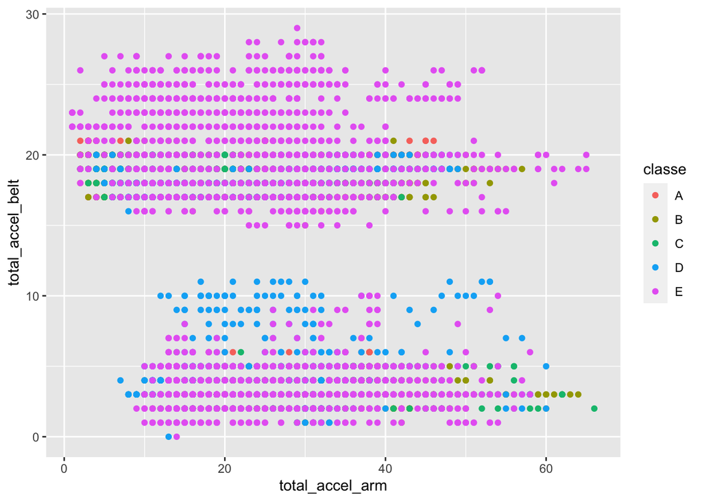

```r
qplot(total_accel_arm, total_accel_belt, colour = classe, data = trainset)
```

```r
set.seed(11111)
modelfit <- rpart(classe ~ ., data = trainset, method = 'class')
```

## Ploting trees

plot normal classification trees and fancy classification trees. Then use trained model to predict data in testing set and check the result. The accuracy of this model is 0.8743

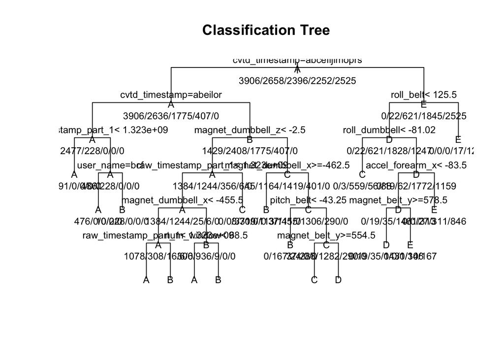

```r
plot(modelfit, uniform = TRUE, main = 'Classification Tree')
text(modelfit, use.n = TRUE, all = TRUE, cex = 0.8)
```

[figure not shown]

```r
fancyRpartPlot(modelfit)
```

```r
predicttree <- predict(modelfit, testset, type = 'class')
cmtree <- confusionMatrix(predicttree, testset$classe)
cmtree
```

```
## Confusion Matrix and Statistics
##
##           Reference
## Prediction    A    B    C    D    E
##          A 1613   51    6    0    0
##          B   43  927   50   42    0
##          C   18  156  942   96   35
##          D    0    5   18  671   55
##          E    0    0   10  155  992
##
## Overall Statistics
##
##                Accuracy : 0.8743
##                  95% CI : (0.8655, 0.8826)
##     No Information Rate : 0.2845
##     P-Value [Acc > NIR] : < 2.2e-16
##
##                   Kappa : 0.8409
##
##  Mcnemar's Test P-Value : NA
##
## Statistics by Class:
##
##                      Class: A Class: B Class: C Class: D Class: E
## Sensitivity            0.9636   0.8139   0.9181   0.6961   0.9168
## Specificity            0.9865   0.9716   0.9372   0.9841   0.9656
## Pos Pred Value         0.9659   0.8729   0.7554   0.8959   0.8574
## Neg Pred Value         0.9855   0.9560   0.9819   0.9430   0.9810
## Prevalence             0.2845   0.1935   0.1743   0.1638   0.1839
## Detection Rate         0.2741   0.1575   0.1601   0.1140   0.1686
## Detection Prevalence   0.2838   0.1805   0.2119   0.1273   0.1966
## Balanced Accuracy      0.9750   0.8927   0.9277   0.8401   0.9412
```

## Random forests

use random forests to train data in training set

```r
controlrf <- trainControl(method="cv", number=3, verboseIter=FALSE)
modelfit2 <- train(classe~., data = trainset, method = 'rf', trControl = controlrf)
modelfit2$finalModel
```

```
##
## Call:
##  randomForest(x = x, y = y, mtry = param$mtry)
##                Type of random forest: classification
##                      Number of trees: 500
## No. of variables tried at each split: 40
##
##         OOB estimate of  error rate: 0.07%
## Confusion matrix:
##      A    B    C    D    E  class.error
## A 3906    0    0    0    0 0.0000000000
## B    1 2656    1    0    0 0.0007524454
## C    0    3 2393    0    0 0.0012520868
## D    0    0    3 2249    0 0.0013321492
## E    0    0    0    1 2524 0.0003960396
```

```r
getTree(modelfit2$finalModel, k=2)
```

[output not shown]

[output cut: 489 more lines]

## Predicting New Values

use trained model to predict data in testing set and check the result of prediction. The accuracy of this model is 0.9995

```r
pred <- predict(modelfit2, testset); testset$predRight <- pred==testset$classe
table(pred, testset$classe)
```

```
##
## pred    A    B    C    D    E
##    A 1674    1    0    0    0
##    B    0 1138    0    0    0
##    C    0    0 1026    0    0
##    D    0    0    0  962    0
##    E    0    0    0    2 1082
```

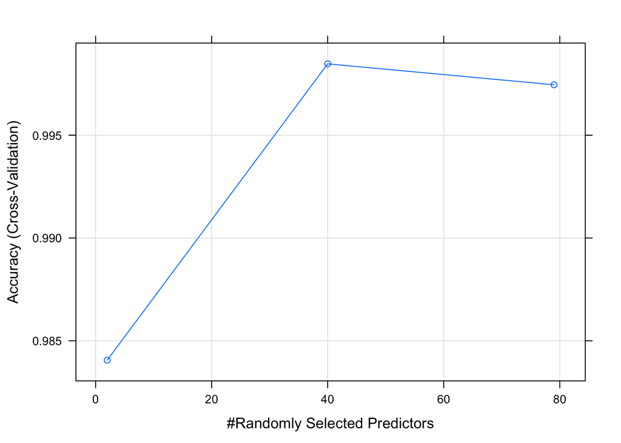

```r
plot(modelfit2)
```

```r
predictrf <- predict(modelfit2, testset)
cmrf <- confusionMatrix(predictrf, testset$classe)
cmrf
```

```
## Confusion Matrix and Statistics
##
##           Reference
## Prediction    A    B    C    D    E
##          A 1674    1    0    0    0
##          B    0 1138    0    0    0
##          C    0    0 1026    0    0
##          D    0    0    0  962    0
##          E    0    0    0    2 1082
##
## Overall Statistics
##
##                Accuracy : 0.9995
##                  95% CI : (0.9985, 0.9999)
##     No Information Rate : 0.2845
##     P-Value [Acc > NIR] : < 2.2e-16
##
##                   Kappa : 0.9994
##
##  Mcnemar's Test P-Value : NA
##
## Statistics by Class:
##
##                      Class: A Class: B Class: C Class: D Class: E
## Sensitivity            1.0000   0.9991   1.0000   0.9979   1.0000
## Specificity            0.9998   1.0000   1.0000   1.0000   0.9996
## Pos Pred Value         0.9994   1.0000   1.0000   1.0000   0.9982
## Neg Pred Value         1.0000   0.9998   1.0000   0.9996   1.0000
## Prevalence             0.2845   0.1935   0.1743   0.1638   0.1839
## Detection Rate         0.2845   0.1934   0.1743   0.1635   0.1839
## Detection Prevalence   0.2846   0.1934   0.1743   0.1635   0.1842
## Balanced Accuracy      0.9999   0.9996   1.0000   0.9990   0.9998
```

## Boosting

use generalized boosted regression to train data in training set and to predict data in testing set. Plot the result of prediction in testing set and check the accuracy of this model(0.9978)

```r
set.seed(11111)
controlgbm <- trainControl(method = "repeatedcv", number = 5, repeats = 1)
modelfit3 <- train(classe~., method = 'gbm', data = trainset, trControl = controlgbm, verbose = FALSE)
modelfit3$finalModel
```

```
## A gradient boosted model with multinomial loss function.
## 150 iterations were performed.
## There were 79 predictors of which 70 had non-zero influence.
```

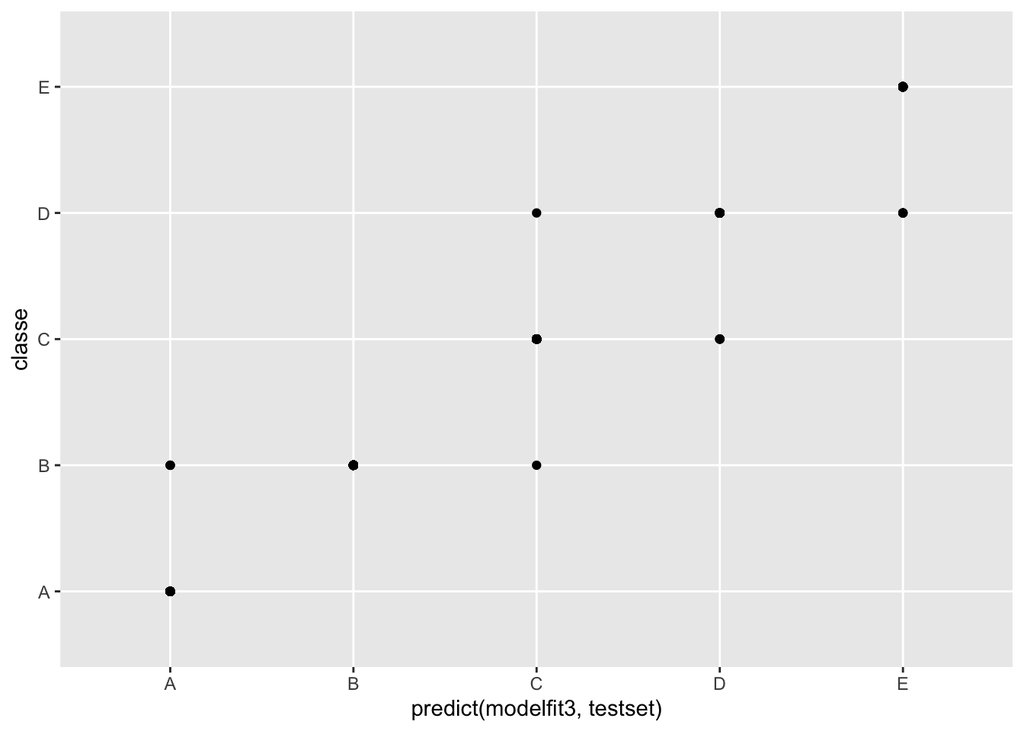

```r
qplot(predict(modelfit3, testset), classe, data = testset)
```

```r
predictboost <- predict(modelfit3, testset)
cmboost <- confusionMatrix(predictboost, testset$classe)
cmboost
```

```
## Confusion Matrix and Statistics
##
##           Reference
## Prediction    A    B    C    D    E
##          A 1674    3    0    0    0
##          B    0 1135    0    0    0
##          C    0    1 1022    1    0
##          D    0    0    4  959    0
##          E    0    0    0    4 1082
##
## Overall Statistics
##
##                Accuracy : 0.9978
##                  95% CI : (0.9962, 0.9988)
##     No Information Rate : 0.2845
##     P-Value [Acc > NIR] : < 2.2e-16
##
##                   Kappa : 0.9972
##
##  Mcnemar's Test P-Value : NA
##
## Statistics by Class:
##
##                      Class: A Class: B Class: C Class: D Class: E
## Sensitivity            1.0000   0.9965   0.9961   0.9948   1.0000
## Specificity            0.9993   1.0000   0.9996   0.9992   0.9992
## Pos Pred Value         0.9982   1.0000   0.9980   0.9958   0.9963
## Neg Pred Value         1.0000   0.9992   0.9992   0.9990   1.0000
## Prevalence             0.2845   0.1935   0.1743   0.1638   0.1839
## Detection Rate         0.2845   0.1929   0.1737   0.1630   0.1839
## Detection Prevalence   0.2850   0.1929   0.1740   0.1636   0.1845
## Balanced Accuracy      0.9996   0.9982   0.9978   0.9970   0.9996
```

## Getting Results from Valide Data

As the accuracy of three models above is 0.8743, 0.9995 and 0.9978 respectively. So use random forests algorithm to predict data in valid dataset

```r
results <- predict(modelfit2, newdata = validdata)
results
```

```
##  [1] B A B A A E D B A A B C B A E E A B B B
## Levels: A B C D E
```